# ExtraaLearn Project

## Decision Tree

### Building Decision Tree Model

```
DecisionTreeClassifier(random_state=1)
```

#### Checking model performance on training set

```
              precision    recall  f1-score   support

           0       1.00      1.00      1.00      2273
           1       1.00      1.00      1.00       955

    accuracy                           1.00      3228
   macro avg       1.00      1.00      1.00      3228
weighted avg       1.00      1.00      1.00      3228
```

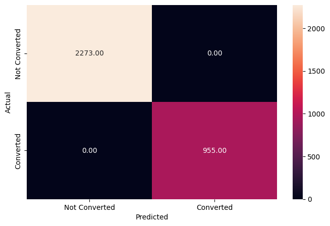

**Observations:**

- The model reached 1.00 accuracy which means that all the samples were correctly classified

**Let's check the performance on test data to see if the model is overfitting.**

```
              precision    recall  f1-score   support

           0       0.87      0.86      0.86       962
           1       0.69      0.70      0.70       422

    accuracy                           0.81      1384
   macro avg       0.78      0.78      0.78      1384
weighted avg       0.81      0.81      0.81      1384
```

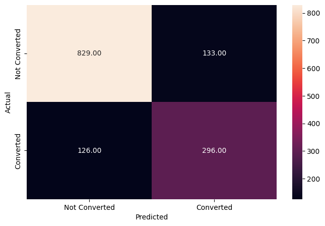

**Observations:**

- precision for not-converted is 0.87, but for converted it is 0.69
- recall and F1-score are 0.86 for non-converted and 0.70 for converted
- accuracy is 0.81
- The model classified 133 cases non-converted as converted and 126 cases of converted as not-converted

**Let's try hyperparameter tuning using GridSearchCV to find the optimal max_depth** to reduce overfitting of the model. We can tune some other hyperparameters as well.

### **Decision Tree - Hyperparameter Tuning**

We will use the class_weight hyperparameter with the value equal to {0: 0.3, 1: 0.7} which is approximately the opposite of the imbalance in the original data.

**This would tell the model that 1 is the important class here.**

```
DecisionTreeClassifier(class_weight={0: 0.3, 1: 0.7}, criterion='entropy',
                       max_depth=np.int64(3), min_samples_leaf=5,
                       random_state=7)
```

We have tuned the model and fit the tuned model on the training data. Now, **let's check the model performance on the training and testing data.**

#### Checking model performance on train and test set

```
              precision    recall  f1-score   support

           0       0.94      0.77      0.85      2273
           1       0.62      0.88      0.73       955

    accuracy                           0.80      3228
   macro avg       0.78      0.83      0.79      3228
weighted avg       0.84      0.80      0.81      3228
```

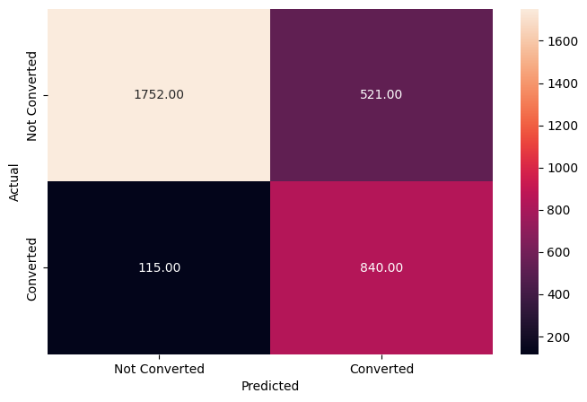

**Observations:**

- Tuned model has reached high recall level for converted leads which is consistent with our priority of minimalisation of loss potential customers

**Let's check the model performance on the testing data**

```
              precision    recall  f1-score   support

           0       0.93      0.77      0.84       962
           1       0.62      0.86      0.72       422

    accuracy                           0.80      1384
   macro avg       0.77      0.82      0.78      1384
weighted avg       0.83      0.80      0.80      1384
```

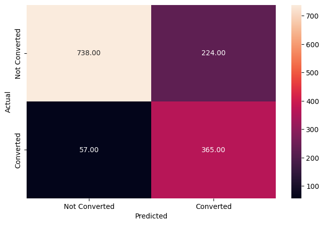

**Observations:**

- accuracy has reached 0.80
- Model correctly classified 86% of real converted customers (recall), it reached better recall in comparison to model before tuning (86% vs 70%)
- The precision for converted has decreased to 62%, which is the consequence of focusing on maximum recall

### Visualizing the Decision Tree

**Let's visualize the tuned decision tree** and observe the decision rules:

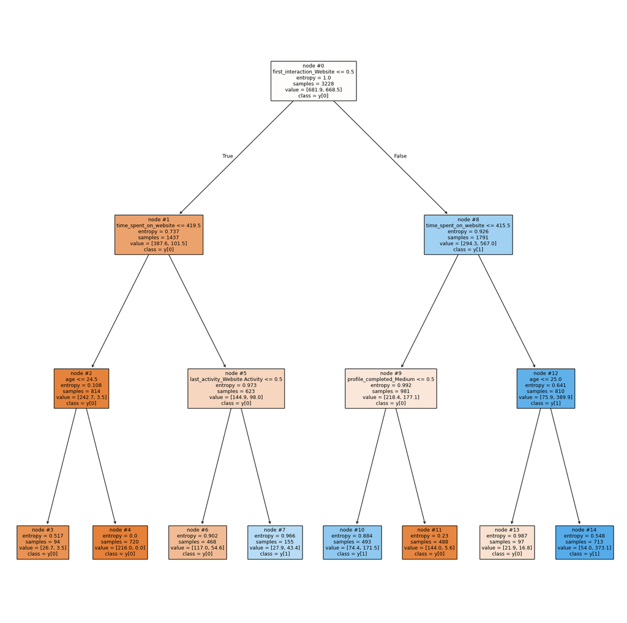

**Observations:** We can specify 3 customer profiles with the biggest chance to conversion:

**Let's look at the feature importance** of the tuned decision tree model

```
                                   Imp
time_spent_on_website          0.34814
first_interaction_Website      0.32718
profile_completed_Medium       0.23927
age                            0.06389
last_activity_Website Activity 0.02151
current_occupation_Student     0.00000
page_views_per_visit           0.00000
website_visits                 0.00000
profile_completed_Low          0.00000
current_occupation_Unemployed  0.00000
last_activity_Phone Activity   0.00000
print_media_type1_Yes          0.00000
print_media_type2_Yes          0.00000
digital_media_Yes              0.00000
educational_channels_Yes       0.00000
referral_Yes                   0.00000
```

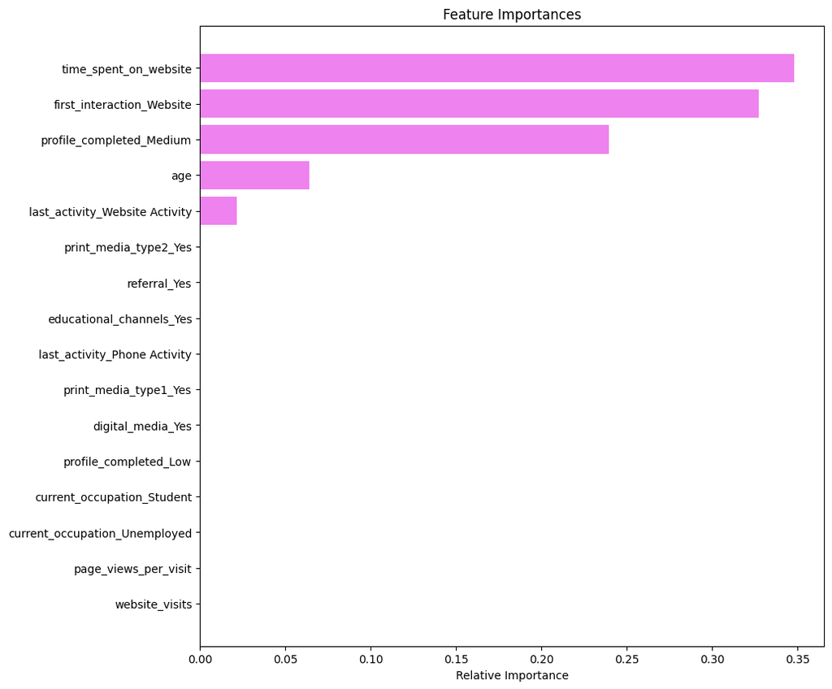

**Observations:**

- **Time spent on the website and first_interaction_website are the most important features** **followed by profile_completed, age, and last_activity**.
- **The rest of the variables have no impact in this model, while deciding whether a lead will be converted or not**.

Now, let's build another model - **a random forest classifier.**

### **Random Forest Classifier**

### Building Random Forest Model

```
RandomForestClassifier(random_state=1)
```

**Let's check the performance of the model on the training data**

```
              precision    recall  f1-score   support

           0       1.00      1.00      1.00      2273
           1       1.00      1.00      1.00       955

    accuracy                           1.00      3228
   macro avg       1.00      1.00      1.00      3228
weighted avg       1.00      1.00      1.00      3228
```

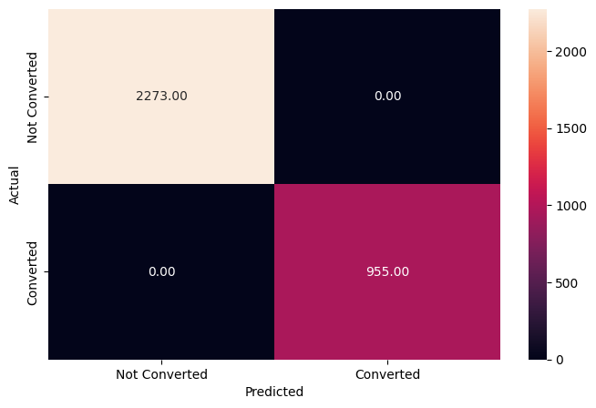

**Observations:**

- The model reached 1.00 accuracy which means that all the samples were correctly classified

**Let's check the performance on the testing data**

```
              precision    recall  f1-score   support

           0       0.87      0.91      0.89       962
           1       0.78      0.68      0.73       422

    accuracy                           0.84      1384
   macro avg       0.82      0.80      0.81      1384
weighted avg       0.84      0.84      0.84      1384
```

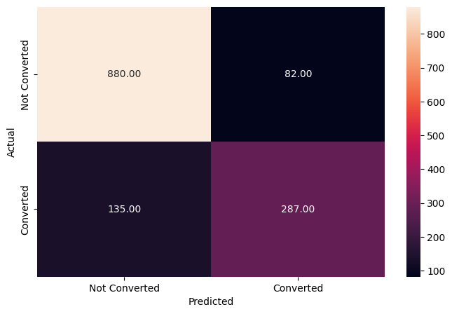

**Observations:**

- The model correctly classified 84% of all cases.
- The model correctly identified 68% of converted clients which is unsatisfactory taking into account out assumptions.
- The model has very good precission 78% for converted clients and it has better results than standard decision tree.

**Let's see if we can get a better model by tuning the random forest classifier**

### **Random Forest Classifier - Hyperparameter Tuning**

Let's try **tuning some of the important hyperparameters of the Random Forest Classifier**.

We will **not** tune the `criterion` hyperparameter as we know from hyperparameter tuning for decision trees that `entropy` is a better splitting criterion for this data.

```
RandomForestClassifier(class_weight='balanced', criterion='entropy',
                       max_depth=6, max_features=0.8, max_samples=0.9,
                       min_samples_leaf=25, n_estimators=120, random_state=7)
```

```
              precision    recall  f1-score   support

           0       0.94      0.83      0.88      2273
           1       0.68      0.87      0.76       955

    accuracy                           0.84      3228
   macro avg       0.81      0.85      0.82      3228
weighted avg       0.86      0.84      0.84      3228
```

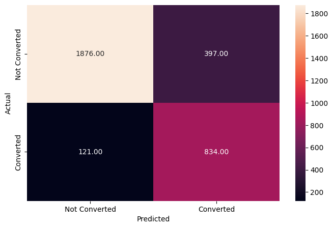

**Let's check the model performance on the test data**

```
              precision    recall  f1-score   support

           0       0.93      0.83      0.87       962
           1       0.68      0.85      0.76       422

    accuracy                           0.83      1384
   macro avg       0.81      0.84      0.82      1384
weighted avg       0.85      0.83      0.84      1384
```

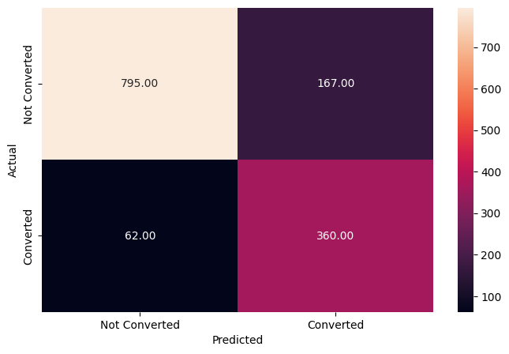

**Observations:**

- The random forest model tuned by entropy the best fit our priorities.
- It has 83% accuracy.
- the recall of converted customers which is the most important variable is 0.85, nevertheless programm has keeped precision also on good level 68%.
- It keept also very good results for non-converted leads.

**One of the drawbacks of ensemble models is that we lose the ability to obtain an interpretation of the model. We cannot observe the decision rules for random forests the way we did for decision trees. So, let's just check the feature importance of the model.**

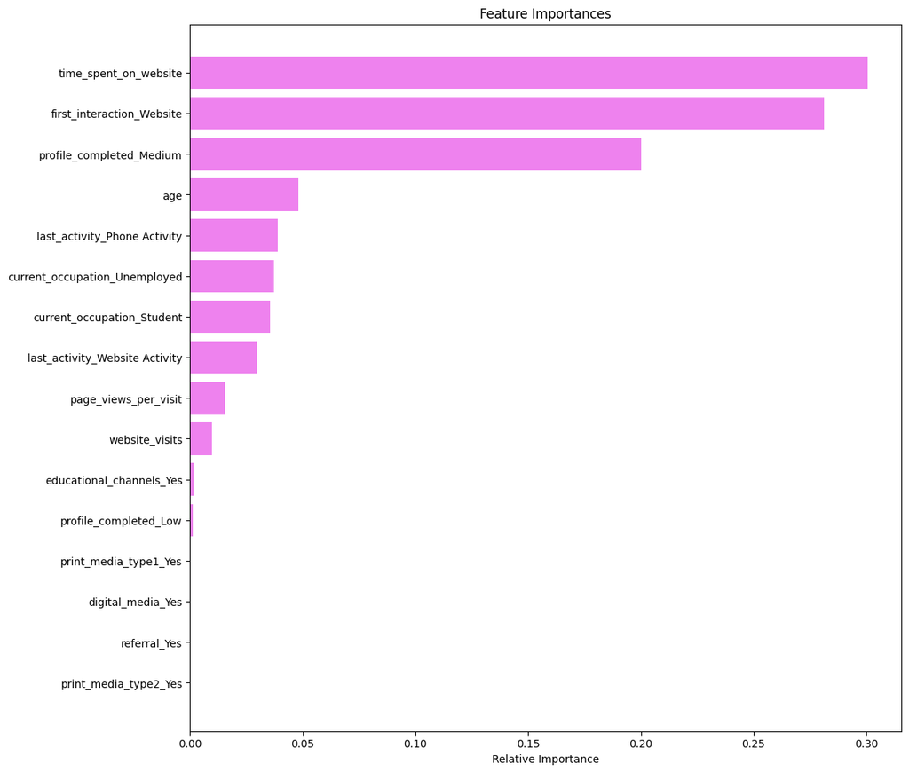

**Observations:**

- Similar to the decision tree model, **time spent on website, first_interaction_website, profile_completed, and age are the top four features** that help distinguish between not converted and converted leads.
- Unlike the decision tree, **the random forest gives some importance to other variables like occupation, page_views_per_visit, as well.** This implies that the random forest is giving importance to more factors in comparison to the decision tree.

## **Conclusion and Recommendations**

### **Conclusions:**

In our analysis we managed to analyze all the data, build a predictive model which allowed us to obtain valuable data.

First, we found the factors driving the conversion process:

- the most important are: time spent on website, first interaction, profile completed and age.
- to a lesser but still significant extent is occupation, the number of views per visit and counts.

Secondly, we also managed to identify the profile of leads with a higher probability of conversion:

### **Business Recommendations:**

Continue to invest in marketing because it is profitable, attracts customers and increases their conversion.

Improve the referral program, because recommended leads have a very high conversion (68%). Offer a faster purchase path, e.g. a dedicated landing page with a "Buy now" button.

Address mainly people who are looking for professional development, because they have the highest conversion.

Dynamically recommend courses based on user behavior and send emails with marketing content tailored to age and profession.

Since time spent on the site is crucial, it is worth focusing on improving UX/UI and providing valuable content.